# Part II - Effects of user characterisctics on duration of trips

## by Lambiv Gills Dzenyuy

## Investigation Overview

In this investigation, I wanted to look at the user characteristics that could be used to predict the duration of these trips. The main focus was on user_type, member_gender and bike_share_for all trip.

## Dataset Overview

There are 183412 individaual bike trips in the dataset with 15 columns covering the data for Chicago bike share for Febuary 2019

## Distibution of trip duration

Duration of trips in the dataset take on a very large range of values,wiht a minimum of 61 seconds to a maximum of 85444 seconds. Plotted on a logarithmic scale, the distribution of trip durations takes a doom shape.

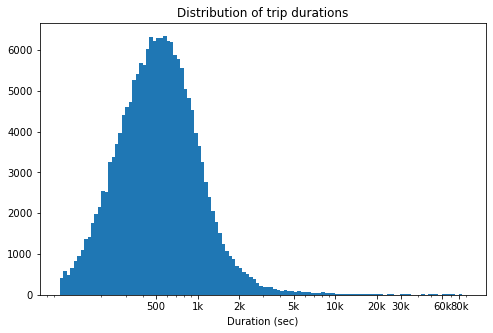

## Duration vs User type

User type is an interesting factor in every organisation or business and is not different for bike share. A plot of duration vs user type indicates that thogh there are many subscribers in each quartile, customers mean duration for each quartile for customers is higher than the corresponding subscriber counterpart.

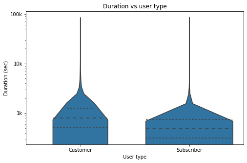

## Duration vs gender distributed by user According to Bike share for all trip

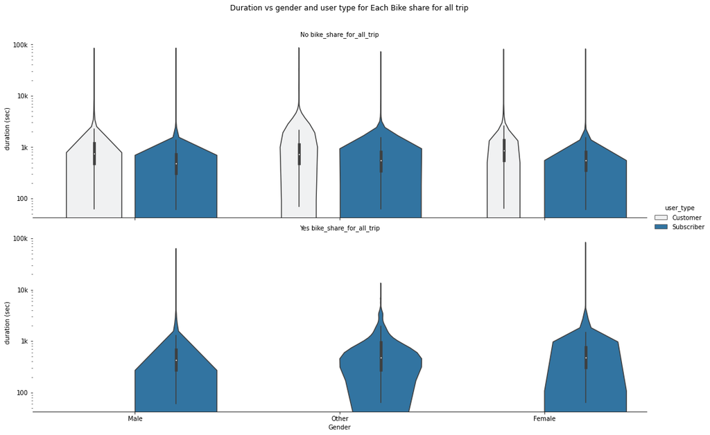

## Duration vs user type with bike share for all trip For Male gender

No bike share for all trip male customers have the highest duration as compared aproximately 0 for those who use bike share in this same category. Male subscribers who use bike share for all trip have slightly high durations than male subscribers who do't

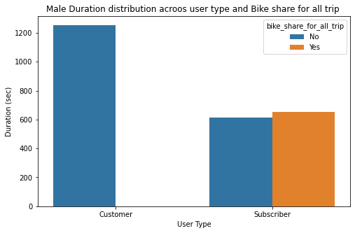

## Duration vs user type with bike share for all trip For Other gender

Other (gender) customers who don't use bike share for all trip have a high mean duration than those who use bike share for all trip and all other subscribers of gender Other. other subscribers who don't use bike share have a mean duration slightly higher than that for those who use bike share for all trip for this same gender

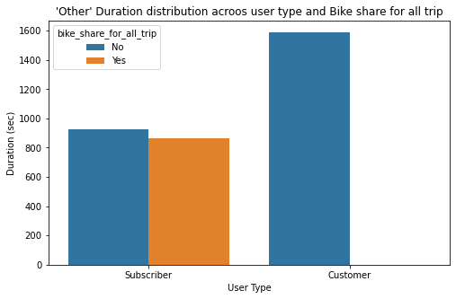